# analysis

```python
import h5py
import numpy as np
import matplotlib.pyplot as plt
```

```python
data = h5py.File('./data.h5', 'r')
reviews = data['reviews']
```

```python
# Average rating of posts that uses more negative words than positive words
np_reviews = np.array(reviews)
neg_word_reviews = np_reviews[np_reviews[:,2]>np_reviews[:,1]]
pos_word_reviews = np_reviews[np_reviews[:,1]>np_reviews[:,2]]
unbiased_word_reviews = np_reviews[np_reviews[:,1] == np_reviews[:,2]]
```

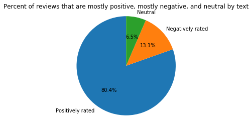

```python
# Pie chart, where the slices will be ordered and plotted counter-clockwise:
plt.clf()
labels = 'Positively rated', 'Negatively rated', 'Neutral'
sizes = [pos_word_reviews.shape[0], neg_word_reviews.shape[0], unbiased_word_reviews.shape[0]]

fig1, ax1 = plt.subplots()
ax1.pie(sizes, labels=labels, autopct='%1.1f%%', startangle=90)
ax1.axis('equal')  # Equal aspect ratio ensures that pie is drawn as a circle.
plt.title('Percent of reviews that are mostly positive, mostly negative, and neutral by text')
plt.show()
```

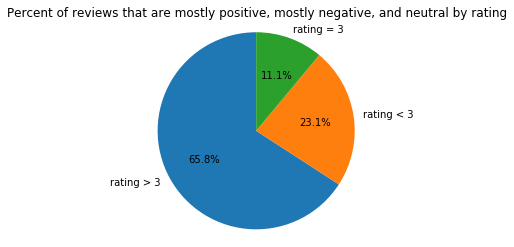

```python
# Pie chart, where the slices will be ordered and plotted counter-clockwise:
plt.clf()
labels = 'rating > 3', 'rating < 3', 'rating = 3'
sizes = [np_reviews[np_reviews[:,0]>3].shape[0], np_reviews[np_reviews[:,0]<3].shape[0], np_reviews[np_reviews[:,0]==3].shape[0]]

fig1, ax1 = plt.subplots()
ax1.pie(sizes, labels=labels, autopct='%1.1f%%', startangle=90)
ax1.axis('equal')  # Equal aspect ratio ensures that pie is drawn as a circle.
plt.title('Percent of reviews that are mostly positive, mostly negative, and neutral by rating')
plt.show()
```

```python
# Positive Words (First 1000 reviews)
fig=plt.figure()
ax=fig.add_axes([0,0,1,1])
ax.scatter(reviews[:1000,0], reviews[:1000,1], color='g')
ax.set_ylabel('Words Counted')
ax.set_xlabel('Rating')
ax.set_title('Relation between positive word count and rating')
plt.xticks([1,2,3,4,5])
plt.ylim(0,50)
plt.show()
```

[output not shown]

```python
# Negative Words (First 1000 reviews)
fig=plt.figure()
ax=fig.add_axes([0,0,1,1])
ax.scatter(reviews[:1000,0], reviews[:1000,2], color='r')
ax.set_ylabel('Words Counted')
ax.set_xlabel('Rating')
ax.set_title('Relation between negative word count and rating')
plt.xticks([1,2,3,4,5])
plt.ylim(0,50)
plt.show()
```

[output not shown]

```python
# Positive Words - Negative Words (First 1000 reviews)
fig=plt.figure()
ax=fig.add_axes([0,0,1,1])
ax.plot(reviews[:1000,0], reviews[:1000,1] - reviews[:1000,2], "o", color='b')
ax.plot([0, 5], [0, 0], 'k-', lw=2)
ax.set_ylabel('Positive Count - Negative Count')
ax.set_xlabel('Rating')
ax.set_title('Relation between positive - negative word count and rating')
plt.xticks([1,2,3,4,5])
plt.show()
```

[output not shown]

```python
fig = plt.figure()
ax = fig.add_axes([0,0,1,1])
ax.hist(reviews[:,0], color='b', bins=[1,2,3,4,5,6], rwidth=0.7)
plt.title('Total Rating Distribution (P(X))')
ax.set_xlabel('rating')
plt.show()
```

[output not shown]

```python
fig = plt.figure()
ax = fig.add_axes([0,0,1,1])
ax.hist(neg_word_reviews[:,0], color='r', bins=[1,2,3,4,5,6], rwidth=0.7)
plt.title('Mostly Negative Rating Distribution (P(X|p < n))')
ax.set_xlabel('rating')
plt.show()
```

[output not shown]

```python
fig = plt.figure()
ax = fig.add_axes([0,0,1,1])
ax.hist(pos_word_reviews[:,0], color='g', bins=[1,2,3,4,5,6], rwidth=0.7)
plt.title('Mostly Positive Rating Distribution (P(X|p > n))')
ax.set_xlabel('rating')
plt.show()
```

[output not shown]

```python
fig = plt.figure()
ax = fig.add_axes([0,0,1,1])
ax.hist(unbiased_word_reviews[:,0], color='y', bins=[1,2,3,4,5,6], rwidth=0.7)
plt.title('Neutral Rating Distribution (P(X|p = n))')
ax.set_xlabel('rating')
plt.show()
```

[output not shown]

```python
print("-----P(x|negative words > positive words)-----")
n_std = np.std(neg_word_reviews[:,0])
print("Standard Deviation:", n_std)
n_mean = np.mean(neg_word_reviews[:,0])
print("Expected Value:", n_mean)

print("-----P(x|positive words > negative words)-----")
p_std = np.std(pos_word_reviews[:,0])
print("Standard Deviation:", p_std)
p_mean = np.mean(pos_word_reviews[:,0])
print("Expected Value:", p_mean)
```

[output not shown]

### When the review is mostly positive

$\mu_p = 4.12016$

$\sigma_p = 1.16839$

### When the review is mostly negative

$\mu_n = 1.74634$

$\sigma_n = 1.18165$

```python
# Overall probability of a rating given no information
print("P(X|p > n)")
for i in range(1,6):
    prob = np.sum(reviews[:,0] == i)/reviews.shape[0]
    print(f"P(x = {i}) = {prob}")

# Probability of a rating given there are more positive keywords than negative keywords
print("P(X|p < n)")
for i in range(1,6):
    prob = np.sum(pos_word_reviews[:,0] == i)/pos_word_reviews.shape[0]
    print(f"P(x = {i}|p > n) = {prob}")

# Probability of a rating given there are more negative keywords than positive keywords
print("P(X|p > n)")
for i in range(1,6):
    prob = np.sum(neg_word_reviews[:,0] == i)/neg_word_reviews.shape[0]
    print(f"P(x = {i}|p > n) = {prob}")

# Probability of a rating given there are negative and positive words are equal (including p = n = 0)
print("P(X|p = n)")
for i in range(1,6):
    prob = np.sum(unbiased_word_reviews[:,0] == i)/unbiased_word_reviews.shape[0]
    print(f"P(x = {i}|p = n) = {prob}")
```

[output not shown]

Let $X \in \{1,2,3,4,5\}$ be a rating, and Let $p$ be the count of positive words for a review, $n$ be the count of negative words for a review. Then, four our dataset, we have the following conditional PMFs:

\begin{equation} P(X) = \begin{cases} 0.14989 & x = 1 \\ 0.08112 & x = 2 \\ 0.11057 & x = 3 \\ 0.21971 & x = 4 \\ 0.43869 & x = 5 \\ \end{cases} \end{equation}\begin{equation} P(X | p > n) = \begin{cases} 0.05700 & x = 1 \\ 0.05889 & x = 2 \\ 0.11099 & x = 3 \\ 0.25312 & x = 4 \\ 0.51997 & x = 5 \\ \end{cases} \end{equation}\begin{equation} P(X | p < n) = \begin{cases} 0.62603 & x = 1 \\ 0.17321 & x = 2 \\ 0.08861 & x = 3 \\ 0.05264 & x = 4 \\ 0.05948 & x = 5 \\ \end{cases} \end{equation}\begin{equation} P(X | p = n) = \begin{cases} 0.33959 & x = 1 \\ 0.17062 & x = 2 \\ 0.14969 & x = 3 \\ 0.14293 & x = 4 \\ 0.19715 & x = 5 \\ \end{cases} \end{equation}

where x is our rating, $x \in \{1,2,3,4,5\}$, p is our count of positive words, and n is our count of negative words.

We've identified our distributions when the review is mostly positive or mostly negative, but now we are going to create a more refined conditional probability. With our dataset, let's find the distribution for every ratio of positive to negative words. Let $W = p + (-n)$. Now lets calculate $P(X|W)$ for all values $W$ in our dataset.

```python
from matplotlib.animation import FuncAnimation, FFMpegWriter

W_score = np_reviews[:,1] - np_reviews[:,2]
W_score = np.sort(W_score)
W_score = np.unique(W_score)

max_W = max(W_score)
min_W = min(W_score)
```

```python
import sys
# Precompute all the probabilities for animation so it doesn't lag while loading
probs = {}
for i in range(10, W_score.size - 10):
    W = W_score[i]
    W_reviews = np_reviews[np_reviews[:,1] - np_reviews[:,2] == W]
    probs[i] = []
    for rating in range(1,6):
        prob = np.sum(W_reviews[:,0] == rating)/W_reviews.shape[0]
        probs[i].append(prob)
    if i % 5 == 0:
        sys.stdout.write(f'\r{i}/{W_score.size}')
        sys.stdout.flush()
```

```python
%matplotlib notebook

fig, ax = plt.subplots()
rects = plt.bar([1,2,3,4,5], [0,0,0,0,0])
plt.ylim(0,1.0)

def update(frame):
    W = W_score[frame + 20]
    for rating in range(1,6):
        rects[rating-1].set_height(probs[frame+20][rating-1])
    plt.title(f"Probability of rating when p - n = {W}")
    return [rect for rect in rects]

anim = FuncAnimation(fig, update, frames=W_score.size - 40, blit=True)
plt.show()
```